# Visualization Analysis (Team-Level)

#### Three Pointer Attempts

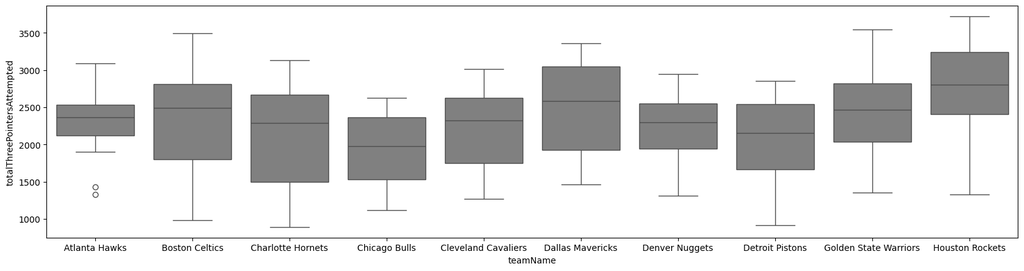

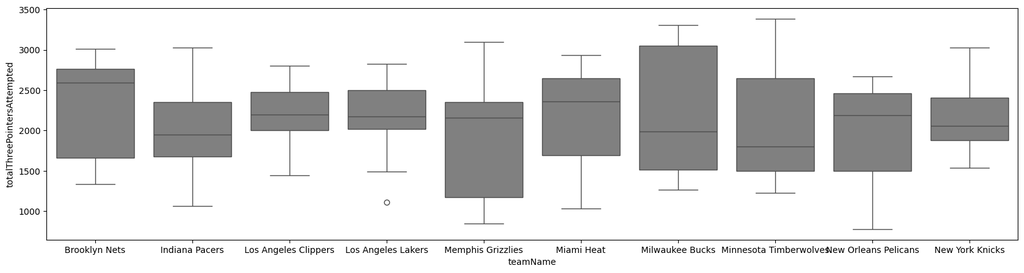

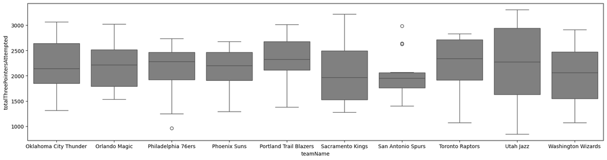

```python
plot_boxplot("totalThreePointersAttempted",regular_season_team_summary_stats_1)
plot_boxplot("totalThreePointersAttempted",regular_season_team_summary_stats_2)
plot_boxplot("totalThreePointersAttempted",regular_season_team_summary_stats_3)
```

For three pointer attempts, Houston Rockets was selected as the higher-performing team while San Antonio Spurs was selected as the lower-performing team.

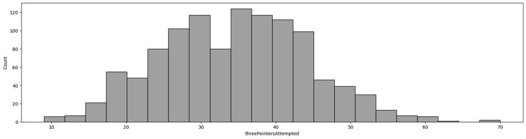

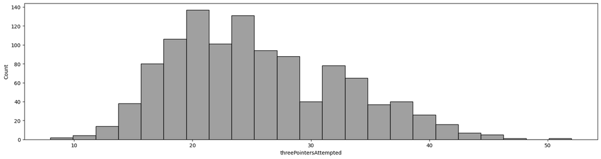

```python
plot_histogram("threePointersAttempted",hou_regular_season_totals)
plot_histogram("threePointersAttempted",sas_regular_season_totals)
plot_barchart("WL",hou_regular_season_totals)
plot_barchart("WL",sas_regular_season_totals)
```

[output not shown]

San Antonio Spurs have more wins than Houston Rockets even though they tend to have less three pointer attempts.

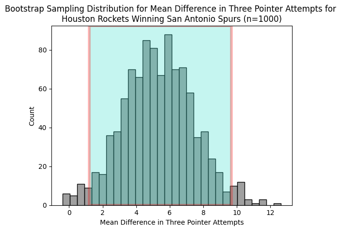

```
[1.197, 9.682999999999996]
```

```python
np.random.seed(100)

combined_games_regular_season["diffThreePointerAttempts"] = combined_games_regular_season["threePointersAttempted_x"] - combined_games_regular_season["threePointersAttempted_y"]

combined_games_play_offs["diffThreePointerAttempts"] = combined_games_play_offs["threePointersAttempted_x"] - combined_games_play_offs["threePointersAttempted_y"]

hou_sas_games = combined_games_regular_season[(combined_games_regular_season["teamName_x"]=="Houston Rockets") & (combined_games_regular_season["teamName_y"]=="San Antonio Spurs")]

hou_sas_three_pointer_attempts_bootstrap_distribution = bootstrap_distribution("diffThreePointerAttempts",hou_sas_games)

hou_sas_three_pointer_attempts_percentile_confidence_interval = confidence_interval(hou_sas_three_pointer_attempts_bootstrap_distribution)

plt.xlabel("Mean Difference in Three Pointer Attempts")
plt.title("Bootstrap Sampling Distribution for Mean Difference in Three Pointer Attempts for \nHouston Rockets Winning San Antonio Spurs (n=1000)")
hou_sas_three_pointer_attempts_confidence_interval = visualize_confidence_interval(hou_sas_three_pointer_attempts_bootstrap_distribution,hou_sas_three_pointer_attempts_percentile_confidence_interval)
print(hou_sas_three_pointer_attempts_percentile_confidence_interval)
```

Unlike attempting field goals, the interval suggests a potential association between attempting more three-pointers and winning. However, as usual, the results by comparing only games with two specific teams could deviate from the entire sample of games. Additionally, the interval is relatively wide, thus having less precision.

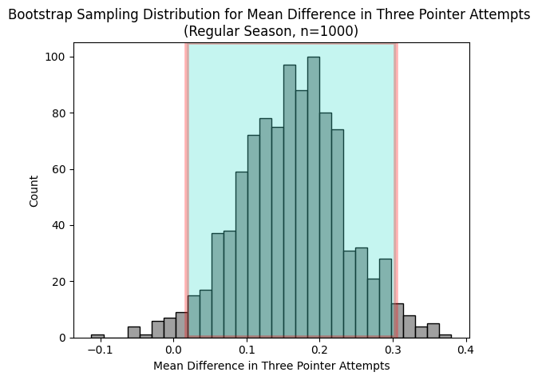

```
[0.017872793852803468, 0.3045053427782447]
```

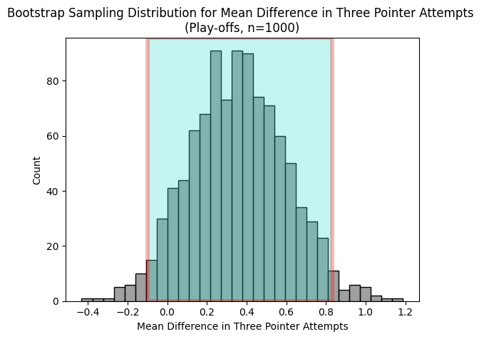

```
[-0.09981296758104738, 0.8305070656691603]
```

```python
np.random.seed(100)

three_pointer_attempts_regular_season_bootstrap_distribution = bootstrap_distribution("diffThreePointerAttempts",combined_games_regular_season)

three_pointer_attempts_regular_season_percentile_confidence_interval = confidence_interval(three_pointer_attempts_regular_season_bootstrap_distribution)

plt.xlabel("Mean Difference in Three Pointer Attempts")
plt.title("Bootstrap Sampling Distribution for Mean Difference in Three Pointer Attempts \n(Regular Season, n=1000)")
three_pointer_attempts_regular_season_confidence_interval = visualize_confidence_interval(three_pointer_attempts_regular_season_bootstrap_distribution,three_pointer_attempts_regular_season_percentile_confidence_interval)
print(three_pointer_attempts_regular_season_percentile_confidence_interval)

three_pointer_attempts_play_offs_bootstrap_distribution = bootstrap_distribution("diffThreePointerAttempts",combined_games_play_offs)

three_pointer_attempts_play_offs_percentile_confidence_interval = confidence_interval(three_pointer_attempts_play_offs_bootstrap_distribution)

plt.xlabel("Mean Difference in Three Pointer Attempts")
plt.title("Bootstrap Sampling Distribution for Mean Difference in Three Pointer Attempts \n(Play-offs, n=1000)")
three_pointer_attempts_play_offs_confidence_interval = visualize_confidence_interval(three_pointer_attempts_play_offs_bootstrap_distribution,three_pointer_attempts_play_offs_percentile_confidence_interval)
print(three_pointer_attempts_play_offs_percentile_confidence_interval)
```

#### Free Throw Attempts

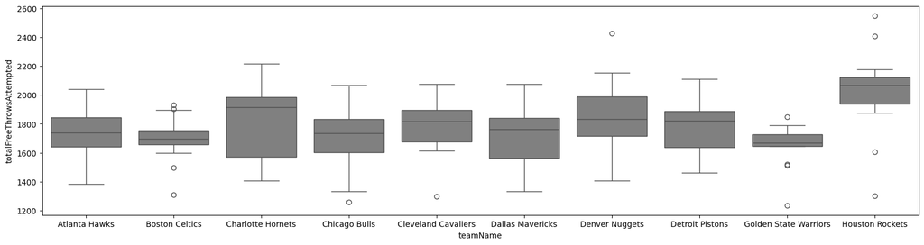

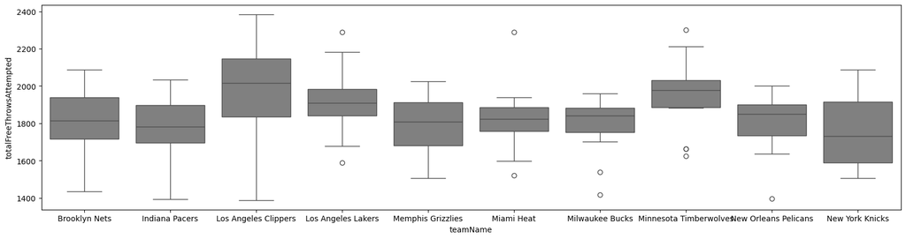

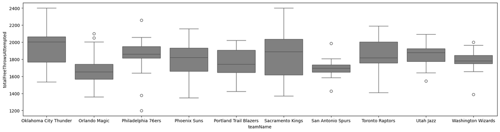

```python
plot_boxplot("totalFreeThrowsAttempted",regular_season_team_summary_stats_1)
plot_boxplot("totalFreeThrowsAttempted",regular_season_team_summary_stats_2)
plot_boxplot("totalFreeThrowsAttempted",regular_season_team_summary_stats_3)
```

For free throw attempts, Houston Rockets was selected as the higher-performing team while Orlando Magic was selected as the lower-performing team.

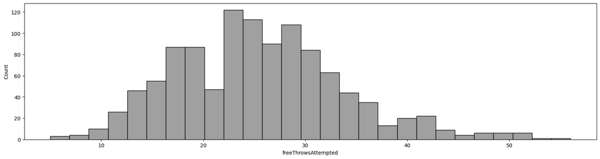

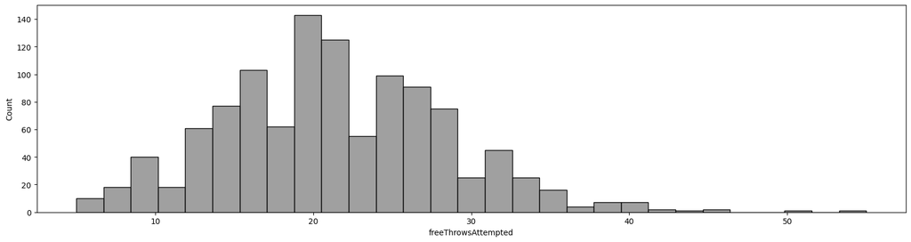

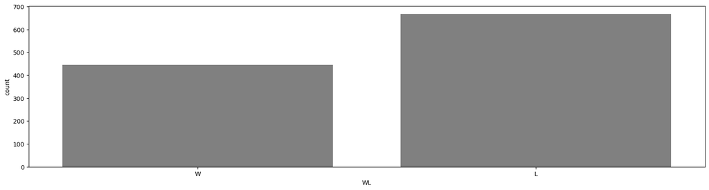

```python
plot_histogram("freeThrowsAttempted",hou_regular_season_totals)
plot_histogram("freeThrowsAttempted",orl_regular_season_totals)
plot_barchart("WL",hou_regular_season_totals)
plot_barchart("WL",orl_regular_season_totals)
```

[output not shown]

Orlando Magic has less wins while also tending to have less free throw attempts.

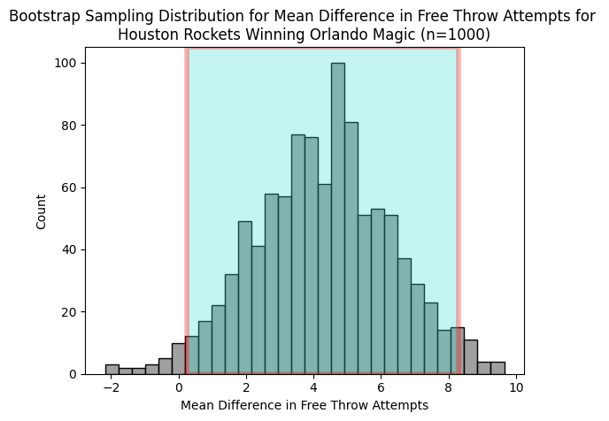

```
[0.2338235294117648, 8.294117647058824]
```

```python
np.random.seed(100)

combined_games_regular_season["diffFreeThrowAttempts"] = combined_games_regular_season["freeThrowsAttempted_x"] - combined_games_regular_season["freeThrowsAttempted_y"]

combined_games_play_offs["diffFreeThrowAttempts"] = combined_games_play_offs["freeThrowsAttempted_x"] - combined_games_play_offs["freeThrowsAttempted_y"]

hou_orl_games["diffFreeThrowAttempts"] = hou_orl_games["freeThrowsAttempted_x"] - hou_orl_games["freeThrowsAttempted_y"]

hou_orl_free_throw_attempts_bootstrap_distribution = bootstrap_distribution("diffFreeThrowAttempts",hou_orl_games)

hou_orl_free_throw_attempts_percentile_confidence_interval = confidence_interval(hou_orl_free_throw_attempts_bootstrap_distribution)

plt.xlabel("Mean Difference in Free Throw Attempts")
plt.title("Bootstrap Sampling Distribution for Mean Difference in Free Throw Attempts for \nHouston Rockets Winning Orlando Magic (n=1000)")
hou_orl_free_throw_attempts_confidence_interval = visualize_confidence_interval(hou_orl_free_throw_attempts_bootstrap_distribution,hou_orl_free_throw_attempts_percentile_confidence_interval)
print(hou_orl_free_throw_attempts_percentile_confidence_interval)
```

Just as the previous team comparison, the interval is wide thus leading to less precision.

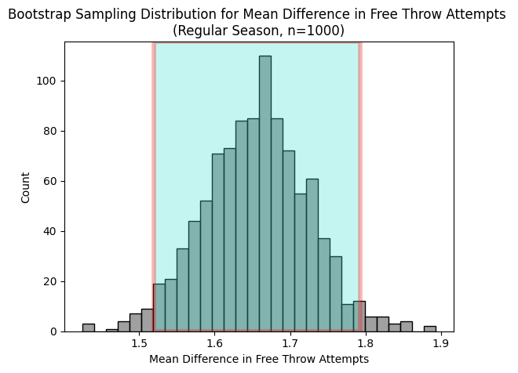

```
[1.5190884259815105, 1.792971845359587]
```

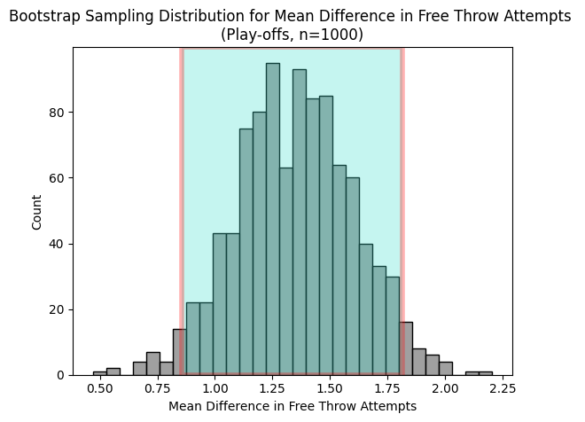

```
[0.857024106400665, 1.8146716541978387]
```

```python
np.random.seed(100)

free_throw_attempts_regular_season_bootstrap_distribution = bootstrap_distribution("diffFreeThrowAttempts",combined_games_regular_season)

free_throw_attempts_regular_season_percentile_confidence_interval = confidence_interval(free_throw_attempts_regular_season_bootstrap_distribution)

plt.xlabel("Mean Difference in Free Throw Attempts")
plt.title("Bootstrap Sampling Distribution for Mean Difference in Free Throw Attempts \n(Regular Season, n=1000)")
free_throw_attempts_regular_season_confidence_interval = visualize_confidence_interval(free_throw_attempts_regular_season_bootstrap_distribution,free_throw_attempts_regular_season_percentile_confidence_interval)
print(free_throw_attempts_regular_season_percentile_confidence_interval)

free_throw_attempts_play_offs_bootstrap_distribution = bootstrap_distribution("diffFreeThrowAttempts",combined_games_play_offs)

free_throw_attempts_play_offs_percentile_confidence_interval = confidence_interval(free_throw_attempts_play_offs_bootstrap_distribution)

plt.xlabel("Mean Difference in Free Throw Attempts")
plt.title("Bootstrap Sampling Distribution for Mean Difference in Free Throw Attempts \n(Play-offs, n=1000)")
free_throw_attempts_play_offs_confidence_interval = visualize_confidence_interval(free_throw_attempts_play_offs_bootstrap_distribution,free_throw_attempts_play_offs_percentile_confidence_interval)
print(free_throw_attempts_play_offs_percentile_confidence_interval)
```

Surprisingly, the intervasl suggests there may be a stronger relationship between having more wins and attempting more free throws when compared to field goal and three pointer attempts. What is also interesting is that when compared to making actual free throws, the interval constructed from using the regular season data spans similar values.

### Final Selections

The regular season data contains approximately 93% of all games in all the data explored while the play-offs data contains approximately 7%. For each of the 95% confidence intervals constructed from each sets of data, the absolute values of the centres of the 95% confidence intervals constructed from using each of the regular season and play-offs data will be divided by their ranges and also multiplied by their respective proportions. This method will focus on variables with mean differences with higher values while also penalizing ones with wider (less precise) intervals. The 6 variables with the greatest computed values will be the top 6 variables selected for statistical modelling.

```python
field_goals_score = score(field_goals_regular_season_percentile_confidence_interval,field_goals_play_offs_percentile_confidence_interval)
print(field_goals_score)

three_pointers_score = score(three_pointers_regular_season_percentile_confidence_interval,three_pointers_play_offs_percentile_confidence_interval)
print(three_pointers_score)

free_throws_score = score(free_throws_regular_season_percentile_confidence_interval,free_throws_play_offs_percentile_confidence_interval)
print(free_throws_score)

rebounds_score = score(rebounds_regular_season_percentile_confidence_interval,rebounds_play_offs_percentile_confidence_interval)
print(rebounds_score)

assists_score = score(assists_regular_season_percentile_confidence_interval,assists_play_offs_percentile_confidence_interval)
print(assists_score)

steals_score = score(steals_regular_season_percentile_confidence_interval,steals_play_offs_percentile_confidence_interval)
print(steals_score)

blocks_score = score(blocks_regular_season_percentile_confidence_interval,blocks_play_offs_percentile_confidence_interval)
print(blocks_score)

fouls_score = score(fouls_regular_season_percentile_confidence_interval,fouls_play_offs_percentile_confidence_interval)
print(fouls_score)

turnovers_score= score(turnovers_regular_season_percentile_confidence_interval,turnovers_play_offs_percentile_confidence_interval)
print(turnovers_score)

field_goal_attempts_score = score(field_goal_attempts_regular_season_percentile_confidence_interval,field_goal_attempts_play_offs_percentile_confidence_interval)
print(field_goal_attempts_score)

three_pointer_attempts_score = score(three_pointer_attempts_regular_season_percentile_confidence_interval,three_pointer_attempts_play_offs_percentile_confidence_interval)
print(three_pointer_attempts_score)

free_throw_attempts_score = score(free_throw_attempts_regular_season_percentile_confidence_interval,free_throw_attempts_play_offs_percentile_confidence_interval)
print(free_throw_attempts_score)
```

```
25.21427763257304
12.544016036174868
7.226050867293867
13.548723813295808
17.99875700853817
5.988458058461015
7.780331863029979
-5.320533006607075
-4.472768029068193
-2.231524564548751
0.5504793504985643
5.720869614037792
```

Based on the computations, field goals, three-pointers, free throws, rebounds, assists, and blocks will be selected as the top half variables to predict wins and losses in statistical modelling.